# Activity Classification Using Machine Learning Model from Data Collected by Personal Electronic Devices

## Summary

Data collected by personal electronic devices can be used perdict the activity the user is performing. Recently, the Human Activity Recognition (HAR) collected data via Inertial Measurement Units (IMU) sensors in order to understand whether how well one performs the activity can be distinguished. Utilizing this dataset collected by HAR, this project aim to build a machine learning model that catagorize different ways the user perform weight lifting exercise.

## Dataset Description

Training and testing dataset were obtained from course website. The original training dataset contains 19622 observations and 160 variables. These data were collected from 6 subjects, each perfromed 5 ways of Unilateral Dumbbell Biceps Curl (hereby referred to as weight lifting). The 5 ways of weight lifting are indicated as A-E in the variable named “classe”. According to HAR, class A is exactly according to the specification, class B is throwing the elbows to the front, class C is lifting the dumbbell only halfway, class D is lowering the dumbbell only halfway, and class E is throwing the hips to the front. The 160 variables of the dataset include subject, time, and data collected from IMU sensors located at different places of the body (belt, arm, forearm and dumbbell). The testing dataset (downloaded from course website, hereby referred to as quiz-testing dataset) contains only 20 observations which was used for the quiz only. A separate testing dataset used for model evaluation was created during pre-processing to better understand the performance of the model.

Refer to Appendis I for codes.

## Exploratory Analysis

It is important to uderstand the distribution of outcome variable among different predictors. To understand this, feature plots were created to show the distribution of class A-E in individual variables after centering and scaling (fig.1). Only selected variables were shown, and these varaibles were selected based on the vairable importance, which will be described later with the model. The feature plots reveal that although there’re some differences, the classes largely overlap with each other.

PCA analysis was also performed on the data after preprocessing (removing unuseful predictors, centering and scaling). Similar to the 1-dimentional feature plot, PCA also did not separate the classes (fig.2). This is because the majority of variation among predictors was not due to the class difference.

#### Figure 1. Distribution plot of selected variables on centered and scaled data

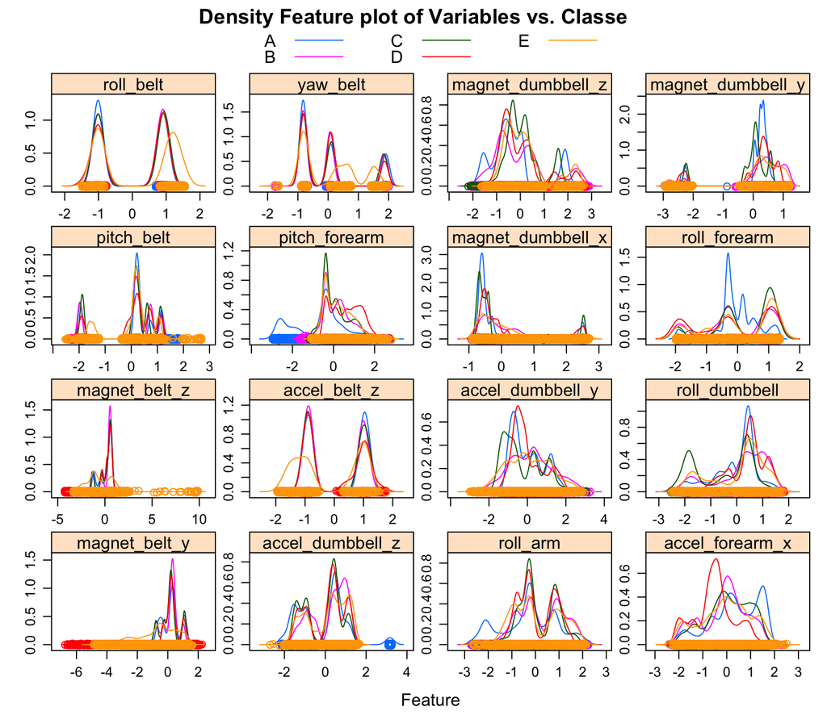

#### Figure 2. PCA plot

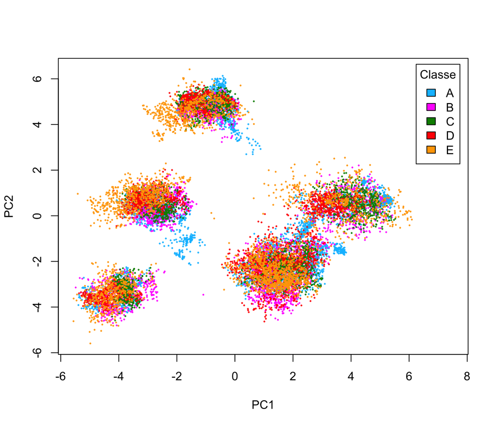

## Model Selection

Multiple factors were taken into consideration for machine learning model selction. First, the dataset consists relatively large number of observations and predictors. Second, the outcome variable, classe, is a factor variable with 5 levels. Third, as revealed in exploratory analysis, the distribution of classes among individual variables were close to each other. Based on these facts, random forest was chosen as the model.

## Preprocessing and Training

To preprocess the the data, user name and near-zero variables from both the training and the quiz-testing datasets were excluded from the predictors. The time variables were also removed, since it is unclear whether time measurement was consistent between different data collection processes. An outlier discovered during exploratory analysis (row 5373) was excluded. Although random forest is generally not sensitive to data distribution, centering and scaling were perfromed in order to accurately calculate variable importance.

The training set downloaded were split randomly into model-training (90% of total) and model-testing (10% of total) datasets. Considering the large size of data and running time, 3-fold cross validation was applied to model training.

## Random Forest Model using All Remaining Variables

First, a random forest model was trainied with all 52 variables remained after pre-processing. An overview of the final model is displayed below. The final model has 500 trees with mtry (variables at each split) of 2. The out-of-bag (OOB) error rate of this model was 0.47%. The error rate was highest for class D and lowest for class A. Variable importance was calculated and displayed in Fig.3; this information was used later to build a simplified random forest model.

#### Random forest model trained with all remaining variables:

```
##
## Call:
##  randomForest(x = x, y = y, mtry = param$mtry)
##                Type of random forest: classification
##                      Number of trees: 500
## No. of variables tried at each split: 2
##
##         OOB estimate of  error rate: 0.47%
## Confusion matrix:
##      A    B    C    D    E  class.error
## A 5020    2    0    0    0 0.0003982477
## B   14 3398    5    0    0 0.0055604331
## C    0   16 3063    1    0 0.0055194805
## D    0    0   39 2854    2 0.0141623489
## E    0    0    0    4 3243 0.0012319064
```

#### Figure 3. Plot of variable importance from the random forest model

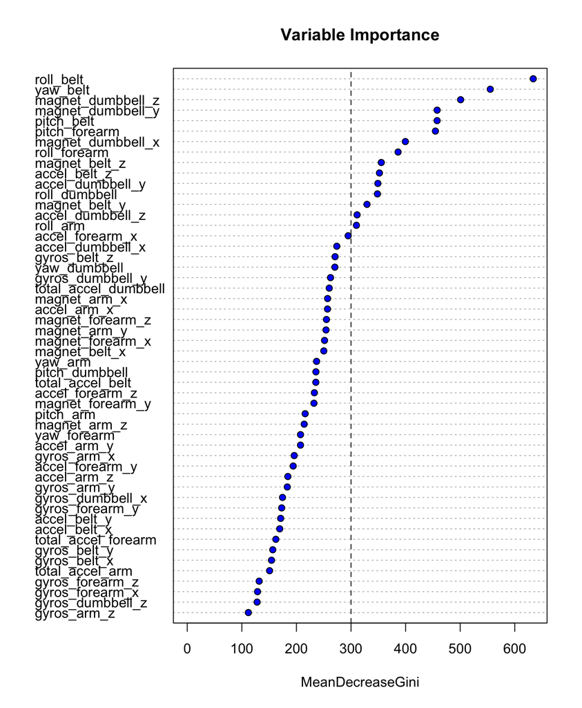

## Random Forest Model with Fewer Predictors

#### Final model of the simplified model:

```
##
## Call:
##  randomForest(x = x, y = y, mtry = param$mtry)
##                Type of random forest: classification
##                      Number of trees: 500
## No. of variables tried at each split: 8
##
##         OOB estimate of  error rate: 0.93%
## Confusion matrix:
##      A    B    C    D    E class.error
## A 5005   10    1    5    1 0.003385106
## B   22 3344   38   13    0 0.021363769
## C    0   12 3053   15    0 0.008766234
## D    0    1   18 2873    3 0.007599309
## E    0    4    7   15 3221 0.008007391
```

#### Comparison of running times between the original and simplified model:

```
## $`Original model, building time:`
##    user  system elapsed
## 322.862   2.498 325.592
##
## $`Simplified model, building time:`
##    user  system elapsed
##  96.418   2.752  99.268
##
## $`Original model, predicting time:`
##    user  system elapsed
##   0.196   0.013   0.209
##
## $`Simplified model, predicting time:`
##    user  system elapsed
##   0.152   0.002   0.154
```